# Customer Churn Analysis

Joao Carlos Casoto Junior

18/11/2021

Clients churn occurs when clients stop their relationship/contracts with a company/service. It is also known as ‘customer attrition’. It is used specially in Telecom department for strategic decision-making process. This code contains the entire process discovery, from data wrangling to ML models implementation. This dataset has been found as an open-source dataset from IBM Sample Data Sets Portal. https://www.ibm.com/communities/analytics/watson-analytics-blog/guide-to-sample-datasets/

```r
# Set working directory
setwd("C:/Users/casoto/Documents/GitHub/portfolio/Other Projects/churn")
getwd()
```

```
## [1] "C:/Users/casoto/Documents/GitHub/portfolio/Other Projects/churn"
```

```r
# Loading Libraries
library(plyr)
library(corrplot)
library(ggplot2)
library(gridExtra)
library(ggthemes)
library(caret)
library(MASS)
library(randomForest)
library(party)
library(Rcpp)
library(caret)
```

## Data Wrangling

```r
churn <- read.csv('Telco-Customer-Churn.csv', stringsAsFactors = T)

dim(churn)
```

```
## [1] 7043   21
```

Raw data contains 7043 rows (clients) and 21 columns (resources). ‘Churn’ is our target variable.

```r
str(churn)
```

```
## 'data.frame':    7043 obs. of  21 variables:
##  $ customerID      : Factor w/ 7043 levels "0002-ORFBO","0003-MKNFE",..: 5376 3963 2565 5536 6512 6552 1003 4771 5605 4535 ...
##  $ gender          : Factor w/ 2 levels "Female","Male": 1 2 2 2 1 1 2 1 1 2 ...
##  $ SeniorCitizen   : int  0 0 0 0 0 0 0 0 0 0 ...
##  $ Partner         : Factor w/ 2 levels "No","Yes": 2 1 1 1 1 1 1 1 2 1 ...
##  $ Dependents      : Factor w/ 2 levels "No","Yes": 1 1 1 1 1 1 2 1 1 2 ...
##  $ tenure          : int  1 34 2 45 2 8 22 10 28 62 ...
##  $ PhoneService    : Factor w/ 2 levels "No","Yes": 1 2 2 1 2 2 2 1 2 2 ...
##  $ MultipleLines   : Factor w/ 3 levels "No","No phone service",..: 2 1 1 2 1 3 3 2 3 1 ...
##  $ InternetService : Factor w/ 3 levels "DSL","Fiber optic",..: 1 1 1 1 2 2 2 1 2 1 ...
##  $ OnlineSecurity  : Factor w/ 3 levels "No","No internet service",..: 1 3 3 3 1 1 1 3 1 3 ...
##  $ OnlineBackup    : Factor w/ 3 levels "No","No internet service",..: 3 1 3 1 1 1 3 1 1 3 ...
##  $ DeviceProtection: Factor w/ 3 levels "No","No internet service",..: 1 3 1 3 1 3 1 1 3 1 ...
##  $ TechSupport     : Factor w/ 3 levels "No","No internet service",..: 1 1 1 3 1 1 1 1 3 1 ...
##  $ StreamingTV     : Factor w/ 3 levels "No","No internet service",..: 1 1 1 1 1 3 3 1 3 1 ...
##  $ StreamingMovies : Factor w/ 3 levels "No","No internet service",..: 1 1 1 1 1 3 1 1 3 1 ...
##  $ Contract        : Factor w/ 3 levels "Month-to-month",..: 1 2 1 2 1 1 1 1 1 2 ...
##  $ PaperlessBilling: Factor w/ 2 levels "No","Yes": 2 1 2 1 2 2 2 1 2 1 ...
##  $ PaymentMethod   : Factor w/ 4 levels "Bank transfer (automatic)",..: 3 4 4 1 3 3 2 4 3 1 ...
##  $ MonthlyCharges  : num  29.9 57 53.9 42.3 70.7 ...
##  $ TotalCharges    : num  29.9 1889.5 108.2 1840.8 151.7 ...
##  $ Churn           : Factor w/ 2 levels "No","Yes": 1 1 2 1 2 2 1 1 2 1 ...
```

Each row represents a client and each column the attributes of this clients.

```r
View(churn)
```

Using sapply to check missing values on each column. There are 11 missing values in column ‘TotalCharges’, which will be removed.

```r
sapply(churn, function(x) sum(is.na(x)))
```

```
##       customerID           gender    SeniorCitizen          Partner
##                0                0                0                0
##       Dependents           tenure     PhoneService    MultipleLines
##                0                0                0                0
##  InternetService   OnlineSecurity     OnlineBackup DeviceProtection
##                0                0                0                0
##      TechSupport      StreamingTV  StreamingMovies         Contract
##                0                0                0                0
## PaperlessBilling    PaymentMethod   MonthlyCharges     TotalCharges
##                0                0                0               11
##            Churn
##                0
```

```r
churn <- churn[complete.cases(churn), ]
```

1. Changing “No internet service” to “No” in the following columns: “OnlineSecurity”, “OnlineBackup”, “DeviceProtection”, “TechSupport”, “streamingTV” and “streamingMovies”.

```r
str(churn)
```

```
## 'data.frame':    7032 obs. of  21 variables:
##  $ customerID      : Factor w/ 7043 levels "0002-ORFBO","0003-MKNFE",..: 5376 3963 2565 5536 6512 6552 1003 4771 5605 4535 ...
##  $ gender          : Factor w/ 2 levels "Female","Male": 1 2 2 2 1 1 2 1 1 2 ...
##  $ SeniorCitizen   : int  0 0 0 0 0 0 0 0 0 0 ...
##  $ Partner         : Factor w/ 2 levels "No","Yes": 2 1 1 1 1 1 1 1 2 1 ...
##  $ Dependents      : Factor w/ 2 levels "No","Yes": 1 1 1 1 1 1 2 1 1 2 ...
##  $ tenure          : int  1 34 2 45 2 8 22 10 28 62 ...
##  $ PhoneService    : Factor w/ 2 levels "No","Yes": 1 2 2 1 2 2 2 1 2 2 ...
##  $ MultipleLines   : Factor w/ 3 levels "No","No phone service",..: 2 1 1 2 1 3 3 2 3 1 ...
##  $ InternetService : Factor w/ 3 levels "DSL","Fiber optic",..: 1 1 1 1 2 2 2 1 2 1 ...
##  $ OnlineSecurity  : Factor w/ 3 levels "No","No internet service",..: 1 3 3 3 1 1 1 3 1 3 ...
##  $ OnlineBackup    : Factor w/ 3 levels "No","No internet service",..: 3 1 3 1 1 1 3 1 1 3 ...
##  $ DeviceProtection: Factor w/ 3 levels "No","No internet service",..: 1 3 1 3 1 3 1 1 3 1 ...
##  $ TechSupport     : Factor w/ 3 levels "No","No internet service",..: 1 1 1 3 1 1 1 1 3 1 ...
##  $ StreamingTV     : Factor w/ 3 levels "No","No internet service",..: 1 1 1 1 1 3 3 1 3 1 ...
##  $ StreamingMovies : Factor w/ 3 levels "No","No internet service",..: 1 1 1 1 1 3 1 1 3 1 ...
##  $ Contract        : Factor w/ 3 levels "Month-to-month",..: 1 2 1 2 1 1 1 1 1 2 ...
##  $ PaperlessBilling: Factor w/ 2 levels "No","Yes": 2 1 2 1 2 2 2 1 2 1 ...
##  $ PaymentMethod   : Factor w/ 4 levels "Bank transfer (automatic)",..: 3 4 4 1 3 3 2 4 3 1 ...
##  $ MonthlyCharges  : num  29.9 57 53.9 42.3 70.7 ...
##  $ TotalCharges    : num  29.9 1889.5 108.2 1840.8 151.7 ...
##  $ Churn           : Factor w/ 2 levels "No","Yes": 1 1 2 1 2 2 1 1 2 1 ...
```

```r
cols_recode1 <- c(10:15)
for(i in 1:ncol(churn[,cols_recode1])) {
  churn[,cols_recode1][,i] <- as.factor(mapvalues
                                        (churn[,cols_recode1][,i], from =c("No internet service"),to=c("No")))
}
head(churn[, cols_recode1])
```

```
##   OnlineSecurity OnlineBackup DeviceProtection TechSupport StreamingTV
## 1             No          Yes               No          No          No
## 2            Yes           No              Yes          No          No
## 3            Yes          Yes               No          No          No
## 4            Yes           No              Yes         Yes          No
## 5             No           No               No          No          No
## 6             No           No              Yes          No         Yes
##   StreamingMovies
## 1              No
## 2              No
## 3              No
## 4              No
## 5              No
## 6             Yes
```

2. Changing “No phone service” to “No” at column “MultipleLines”

```r
churn$MultipleLines <- as.factor(mapvalues(churn$MultipleLines,
                                           from=c("No phone service"),
                                           to=c("No")))
head(churn$MultipleLines)
```

```
## [1] No  No  No  No  No  Yes
## Levels: No Yes
```

3. Minimum ternure is 1 month and maximum 72 months. We can group into five ranges, like the following: “0-12”, “12–24”, “24–48”, “48–60” and “>60”

```r
min(churn$tenure); max(churn$tenure)
```

```
## [1] 1
```

```
## [1] 72
```

```r
group_tenure <- function(tenure){
  if (tenure >= 0 & tenure <= 12){
    return('0-12 Month')
  }else if(tenure > 12 & tenure <= 24){
    return('12-24 Month')
  }else if (tenure > 24 & tenure <= 48){
    return('24-48 Month')
  }else if (tenure > 48 & tenure <=60){
    return('48-60 Month')
  }else if (tenure > 60){
    return('> 60 Month')
  }
}

churn$tenure_group <- sapply(churn$tenure,group_tenure)
churn$tenure_group <- as.factor(churn$tenure_group)
head(churn$tenure_group)
```

```
## [1] 0-12 Month  24-48 Month 0-12 Month  24-48 Month 0-12 Month  0-12 Month
## Levels: > 60 Month 0-12 Month 12-24 Month 24-48 Month 48-60 Month
```

4. Changing values in “SeniorCitizen” column from 0/1 to No/Yes.

```r
churn$SeniorCitizen <- as.factor(mapvalues(churn$SeniorCitizen,
                                           from=c("0","1"),
                                           to=c("No", "Yes")))

head(churn$SeniorCitizen)
```

```
## [1] No No No No No No
## Levels: No Yes
```

```r
# 5. Removing unwanted columns
churn$customerID <- NULL
churn$tenure <- NULL
View(churn)
```

## Exploratory Analysis & Feature Selection

Checking correlation between quantitative variables

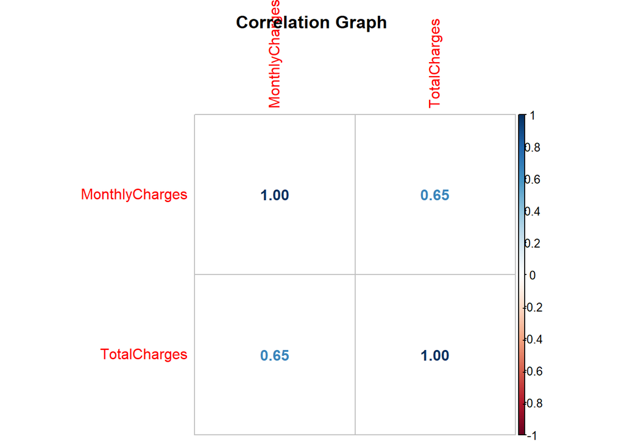

```r
numeric.var <- sapply(churn, is.numeric)
corr.matrix <- cor(churn[,numeric.var])
corrplot(corr.matrix, main="\n\nCorrelation Graph", method="number")
```

There is a medium-strong correlation between Monthly Charges and Total Charges. We’ll remove TotalCharges column for this model consolidation (multicollinearity).

```r
churn$TotalCharges <- NULL
```

Barcharts for categorical columns

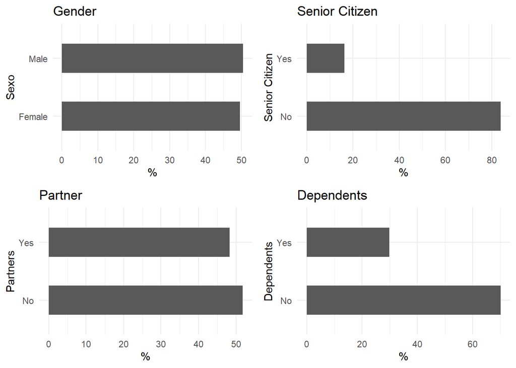

```r
p1 <- ggplot(churn, aes(x=gender)) + ggtitle("Gender") + xlab("Sexo") +
  geom_bar(aes(y = 100*(..count..)/sum(..count..)), width = 0.5) + ylab("%") + coord_flip() + theme_minimal()
p2 <- ggplot(churn, aes(x=SeniorCitizen)) + ggtitle("Senior Citizen") + xlab("Senior Citizen") +
  geom_bar(aes(y = 100*(..count..)/sum(..count..)), width = 0.5) + ylab("%") + coord_flip() + theme_minimal()
p3 <- ggplot(churn, aes(x=Partner)) + ggtitle("Partner") + xlab("Partners") +
  geom_bar(aes(y = 100*(..count..)/sum(..count..)), width = 0.5) + ylab("%") + coord_flip() + theme_minimal()
p4 <- ggplot(churn, aes(x=Dependents)) + ggtitle("Dependents") + xlab("Dependents") +
  geom_bar(aes(y = 100*(..count..)/sum(..count..)), width = 0.5) + ylab("%") + coord_flip() + theme_minimal()
grid.arrange(p1, p2, p3, p4, ncol=2)
```

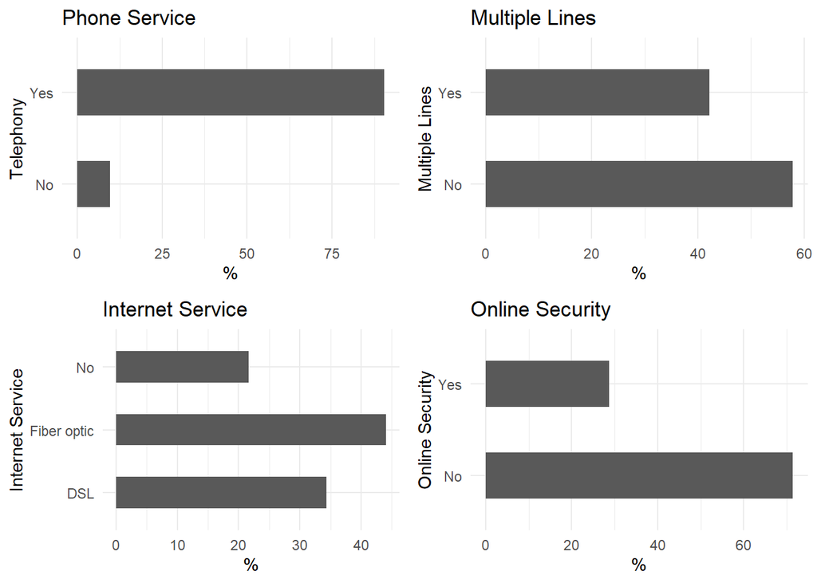

```r
p5 <- ggplot(churn, aes(x=PhoneService)) + ggtitle("Phone Service") + xlab("Telephony") +
  geom_bar(aes(y = 100*(..count..)/sum(..count..)), width = 0.5) + ylab("%") + coord_flip() + theme_minimal()
p6 <- ggplot(churn, aes(x=MultipleLines)) + ggtitle("Multiple Lines") + xlab("Multiple Lines") +
  geom_bar(aes(y = 100*(..count..)/sum(..count..)), width = 0.5) + ylab("%") + coord_flip() + theme_minimal()
p7 <- ggplot(churn, aes(x=InternetService)) + ggtitle("Internet Service") + xlab("Internet Service") +
  geom_bar(aes(y = 100*(..count..)/sum(..count..)), width = 0.5) + ylab("%") + coord_flip() + theme_minimal()
p8 <- ggplot(churn, aes(x=OnlineSecurity)) + ggtitle("Online Security") + xlab("Online Security") +
  geom_bar(aes(y = 100*(..count..)/sum(..count..)), width = 0.5) + ylab("%") + coord_flip() + theme_minimal()
grid.arrange(p5, p6, p7, p8, ncol=2)
```

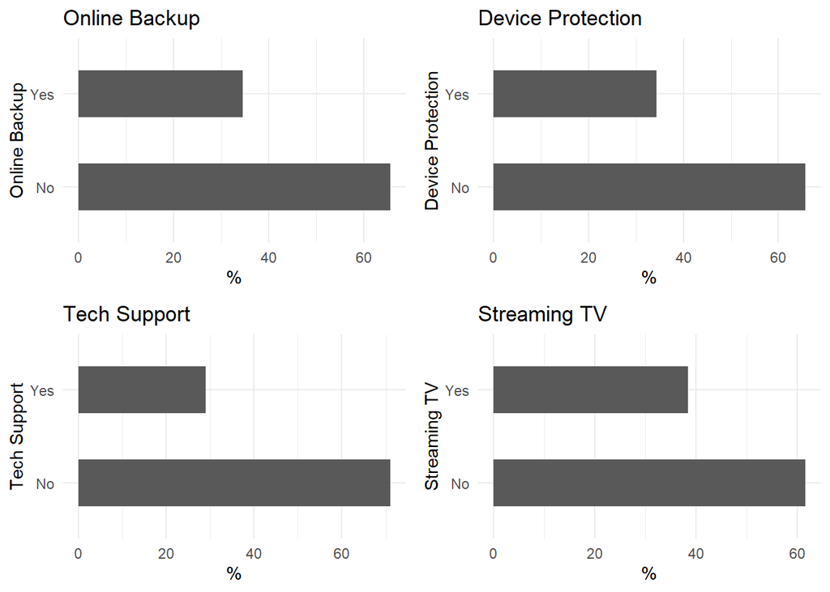

```r
p9 <- ggplot(churn, aes(x=OnlineBackup)) + ggtitle("Online Backup") + xlab("Online Backup") +
  geom_bar(aes(y = 100*(..count..)/sum(..count..)), width = 0.5) + ylab("%") + coord_flip() + theme_minimal()
p10 <- ggplot(churn, aes(x=DeviceProtection)) + ggtitle("Device Protection") + xlab("Device Protection") +
  geom_bar(aes(y = 100*(..count..)/sum(..count..)), width = 0.5) + ylab("%") + coord_flip() + theme_minimal()
p11 <- ggplot(churn, aes(x=TechSupport)) + ggtitle("Tech Support") + xlab("Tech Support") +
  geom_bar(aes(y = 100*(..count..)/sum(..count..)), width = 0.5) + ylab("%") + coord_flip() + theme_minimal()
p12 <- ggplot(churn, aes(x=StreamingTV)) + ggtitle("Streaming TV") + xlab("Streaming TV") +
  geom_bar(aes(y = 100*(..count..)/sum(..count..)), width = 0.5) + ylab("%") + coord_flip() + theme_minimal()
grid.arrange(p9, p10, p11, p12, ncol=2)
```

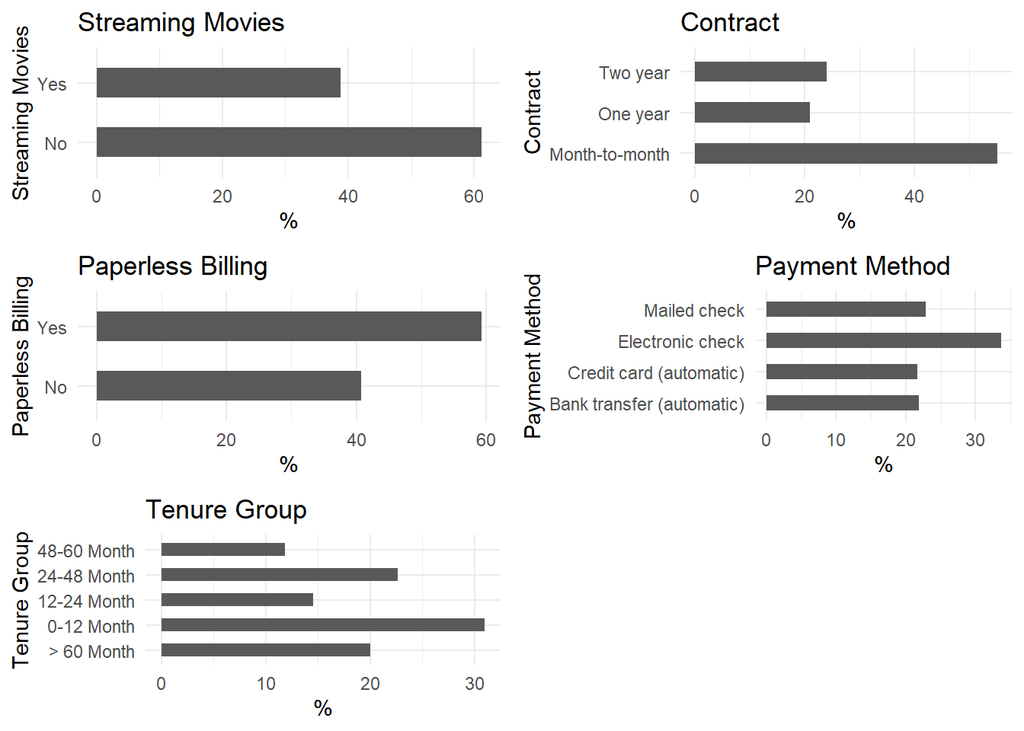

```r
p13 <- ggplot(churn, aes(x=StreamingMovies)) + ggtitle("Streaming Movies") + xlab("Streaming Movies") +
  geom_bar(aes(y = 100*(..count..)/sum(..count..)), width = 0.5) + ylab("%") + coord_flip() + theme_minimal()
p14 <- ggplot(churn, aes(x=Contract)) + ggtitle("Contract") + xlab("Contract") +
  geom_bar(aes(y = 100*(..count..)/sum(..count..)), width = 0.5) + ylab("%") + coord_flip() + theme_minimal()
p15 <- ggplot(churn, aes(x=PaperlessBilling)) + ggtitle("Paperless Billing") + xlab("Paperless Billing") +
  geom_bar(aes(y = 100*(..count..)/sum(..count..)), width = 0.5) + ylab("%") + coord_flip() + theme_minimal()
p16 <- ggplot(churn, aes(x=PaymentMethod)) + ggtitle("Payment Method") + xlab("Payment Method") +
  geom_bar(aes(y = 100*(..count..)/sum(..count..)), width = 0.5) + ylab("%") + coord_flip() + theme_minimal()
p17 <- ggplot(churn, aes(x=tenure_group)) + ggtitle("Tenure Group") + xlab("Tenure Group") +
  geom_bar(aes(y = 100*(..count..)/sum(..count..)), width = 0.5) + ylab("%") + coord_flip() + theme_minimal()
grid.arrange(p13, p14, p15, p16, p17, ncol=2)
```

Split data into train and test subsets

```r
intrain <- createDataPartition(churn$Churn,p=0.7,list=FALSE)
set.seed(2017)
training <- churn[intrain,]
testing <- churn[-intrain,]
```

Checking split size

```r
dim(training)
```

```
## [1] 4924   19
```

```r
dim(testing)
```

```
## [1] 2108   19
```

Training model & Model fitting

```r
LogModel <- glm(Churn ~ ., family=binomial(link="logit"), data=training)
print(summary(LogModel))
```

```
##
## Call:
## glm(formula = Churn ~ ., family = binomial(link = "logit"), data = training)
##
## Deviance Residuals:
##     Min       1Q   Median       3Q      Max
## -1.9700  -0.6806  -0.2916   0.6790   3.1413
##
## Coefficients:
##                                      Estimate Std. Error z value Pr(>|z|)
## (Intercept)                          -1.03347    0.98562  -1.049 0.294388
## genderMale                           -0.08297    0.07749  -1.071 0.284280
## SeniorCitizenYes                      0.21598    0.10122   2.134 0.032859 *
## PartnerYes                            0.08398    0.09347   0.898 0.368926
## DependentsYes                        -0.23748    0.10625  -2.235 0.025405 *
## PhoneServiceYes                       0.10672    0.77343   0.138 0.890249
## MultipleLinesYes                      0.38151    0.21089   1.809 0.070443 .
## InternetServiceFiber optic            1.51959    0.95073   1.598 0.109965
## InternetServiceNo                    -1.65561    0.96210  -1.721 0.085282 .
## OnlineSecurityYes                    -0.37053    0.21221  -1.746 0.080802 .
## OnlineBackupYes                      -0.08295    0.20913  -0.397 0.691625
## DeviceProtectionYes                   0.07062    0.20923   0.338 0.735712
## TechSupportYes                       -0.21103    0.21536  -0.980 0.327133
## StreamingTVYes                        0.49252    0.38974   1.264 0.206331
## StreamingMoviesYes                    0.54592    0.39058   1.398 0.162201
## ContractOne year                     -0.69479    0.12594  -5.517 3.45e-08 ***
## ContractTwo year                     -1.68708    0.22103  -7.633 2.30e-14 ***
## PaperlessBillingYes                   0.26658    0.08831   3.019 0.002540 **
## PaymentMethodCredit card (automatic) -0.03445    0.13467  -0.256 0.798078
## PaymentMethodElectronic check         0.32966    0.11210   2.941 0.003274 **
## PaymentMethodMailed check            -0.05019    0.13582  -0.369 0.711766
## MonthlyCharges                       -0.02750    0.03784  -0.727 0.467378
## tenure_group0-12 Month                1.65150    0.20290   8.140 3.97e-16 ***
## tenure_group12-24 Month               0.71728    0.19958   3.594 0.000326 ***
## tenure_group24-48 Month               0.40692    0.18163   2.240 0.025062 *
## tenure_group48-60 Month               0.20638    0.19499   1.058 0.289854
## ---
## Signif. codes:  0 '***' 0.001 '**' 0.01 '*' 0.05 '.' 0.1 ' ' 1
##
## (Dispersion parameter for binomial family taken to be 1)
##
##     Null deviance: 5702.8  on 4923  degrees of freedom
## Residual deviance: 4112.7  on 4898  degrees of freedom
## AIC: 4164.7
##
## Number of Fisher Scoring iterations: 6
```

## Variance Analysis - ANOVA

The three most-relevant variables in this model are: ‘Contract’, ‘tenure_group’ and ‘PaperlessBilling.’

```r
anova(LogModel, test="Chisq")
```

```
## Analysis of Deviance Table
##
## Model: binomial, link: logit
##
## Response: Churn
##
## Terms added sequentially (first to last)
##
##
##                  Df Deviance Resid. Df Resid. Dev  Pr(>Chi)
## NULL                              4923     5702.8
## gender            1     1.29      4922     5701.5   0.25577
## SeniorCitizen     1   113.54      4921     5587.9 < 2.2e-16 ***
## Partner           1   101.29      4920     5486.6 < 2.2e-16 ***
## Dependents        1    38.36      4919     5448.3 5.887e-10 ***
## PhoneService      1     0.32      4918     5448.0   0.57137
## MultipleLines     1     3.36      4917     5444.6   0.06688 .
## InternetService   2   456.03      4915     4988.6 < 2.2e-16 ***
## OnlineSecurity    1   201.99      4914     4786.6 < 2.2e-16 ***
## OnlineBackup      1    86.52      4913     4700.1 < 2.2e-16 ***
## DeviceProtection  1    48.10      4912     4652.0 4.048e-12 ***
## TechSupport       1    80.37      4911     4571.6 < 2.2e-16 ***
## StreamingTV       1     0.40      4910     4571.2   0.52454
## StreamingMovies   1     0.57      4909     4570.6   0.45172
## Contract          2   266.22      4907     4304.4 < 2.2e-16 ***
## PaperlessBilling  1     9.32      4906     4295.1   0.00227 **
## PaymentMethod     3    30.33      4903     4264.8 1.176e-06 ***
## MonthlyCharges    1     0.91      4902     4263.9   0.34086
## tenure_group      4   151.14      4898     4112.7 < 2.2e-16 ***
## ---
## Signif. codes:  0 '***' 0.001 '**' 0.01 '*' 0.05 '.' 0.1 ' ' 1
```

While analyzing the variance table, we can see significant drops directly related to the quantity of variables. Adding ‘InternetService’, ‘Contract’ and ‘tenure_group’ reduces significantly the residual values. But for other variables such as ‘PaymentMethod’ and ‘Dependents’ seem to improve less the current model, even though they have low p-values (checking accuracy).

```r
testing$Churn <- as.character(testing$Churn)
testing$Churn[testing$Churn=="No"] <- "0"
testing$Churn[testing$Churn=="Yes"] <- "1"
fitted.results <- predict(LogModel,newdata=testing,type='response')
fitted.results <- ifelse(fitted.results > 0.5,1,0)
misClasificError <- mean(fitted.results != testing$Churn)
print(paste('Logistic Regression Accuracy',1-misClasificError)) # 80% of accuracy!
```

```
## [1] "Logistic Regression Accuracy 0.797912713472486"
```

Logistics Regression Confusion Matrix (Errors Type I and II)

```r
print("Logistics Regression Confusion Matrix"); table(testing$Churn, fitted.results > 0.5)
```

```
## [1] "Logistics Regression Confusion Matrix"
```

```
##
##     FALSE TRUE
##   0  1394  154
##   1   272  288
```

Odds Ratio calculation

```r
exp(cbind(OR=coef(LogModel), confint(LogModel)))
```

```
##                                             OR      2.5 %     97.5 %
## (Intercept)                          0.3557713 0.05146966  2.4545851
## genderMale                           0.9203807 0.79064105  1.0713152
## SeniorCitizenYes                     1.2410762 1.01750704  1.5132023
## PartnerYes                           1.0876092 0.90571671  1.3066434
## DependentsYes                        0.7886103 0.63983165  0.9705247
## PhoneServiceYes                      1.1126279 0.24440662  5.0720646
## MultipleLinesYes                     1.4644875 0.96899347  2.2153533
## InternetServiceFiber optic           4.5703611 0.71053418 29.5522253
## InternetServiceNo                    0.1909750 0.02891901  1.2576280
## OnlineSecurityYes                    0.6903701 0.45514611  1.0459856
## OnlineBackupYes                      0.9203964 0.61080624  1.3868458
## DeviceProtectionYes                  1.0731748 0.71215070  1.6175812
## TechSupportYes                       0.8097485 0.53062524  1.2346120
## StreamingTVYes                       1.6364290 0.76278455  3.5162992
## StreamingMoviesYes                   1.7261884 0.80344091  3.7160143
## ContractOne year                     0.4991797 0.38899307  0.6374987
## ContractTwo year                     0.1850600 0.11824541  0.2817872
## PaperlessBillingYes                  1.3054948 1.09826510  1.5527212
## PaymentMethodCredit card (automatic) 0.9661327 0.74174653  1.2578813
## PaymentMethodElectronic check        1.3904946 1.11704723  1.7337642
## PaymentMethodMailed check            0.9510533 0.72898366  1.2417523
## MonthlyCharges                       0.9728769 0.90325827  1.0477181
## tenure_group0-12 Month               5.2147767 3.51619258  7.7932445
## tenure_group12-24 Month              2.0488590 1.38922937  3.0394935
## tenure_group24-48 Month              1.5021883 1.05536835  2.1523606
## tenure_group48-60 Month              1.2292248 0.83916709  1.8037468
```

## Decision Tree Algorithm Implementation

Sample plotting using ‘Contract’, ‘tenure_group’ and PaperlessBilling’ columns (most relevant in model summary)

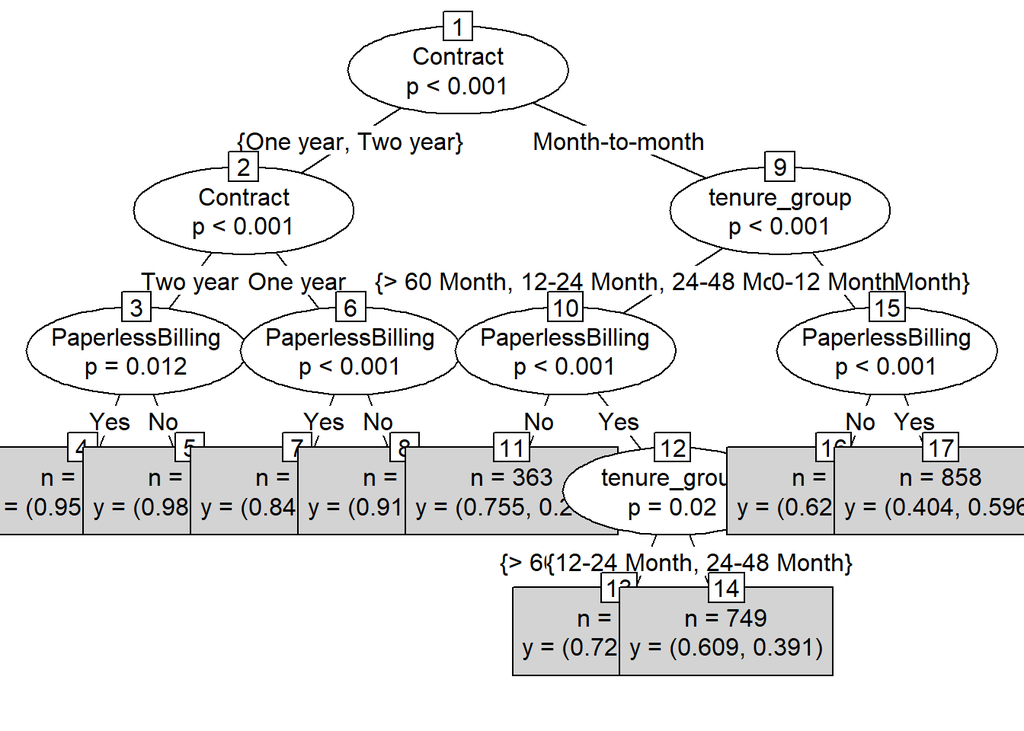

```r
tree <- ctree(Churn ~ Contract+tenure_group+PaperlessBilling, training)
plot(tree, type='simple')
```

INTERPRETATION: For the tree used variables, Contract is the most important to predict clients rotation. Checking if the client has a one-year or two-year contract is also a good predictor, which brings a better stability for customer basis. In other hand, the odds of revoking the contract are higher if a client has a monthly contract (right branch) with a paperless billing model.

```r
pred_tree <- predict(tree, testing)
print("Decision Tree Confusion Matrix"); table(Predicted = pred_tree, Actual = testing$Churn)
```

```
## [1] "Decision Tree Confusion Matrix"
```

```
##          Actual
## Predicted    0    1
##       No  1396  338
##       Yes  152  222
```

Predictions

```r
p1 <- predict(tree, training)
tab1 <- table(Predicted = p1, Actual = training$Churn)
tab2 <- table(Predicted = pred_tree, Actual = testing$Churn)
print(paste('Decision Tree Accuracy',sum(diag(tab2))/sum(tab2))) # 76% accuracy, lower than GLM
```

```
## [1] "Decision Tree Accuracy 0.767552182163188"
```

## Random Forest Model Implementation

```r
set.seed(2017)
?randomForest
```

```
## starting httpd help server ... done
```

```r
rfModel <- randomForest(Churn ~ ., data = training)
print(rfModel)
```

```
##
## Call:
##  randomForest(formula = Churn ~ ., data = training)
##                Type of random forest: classification
##                      Number of trees: 500
## No. of variables tried at each split: 4
##
##         OOB estimate of  error rate: 21.49%
## Confusion matrix:
##       No Yes class.error
## No  3234 381   0.1053942
## Yes  677 632   0.5171887
```

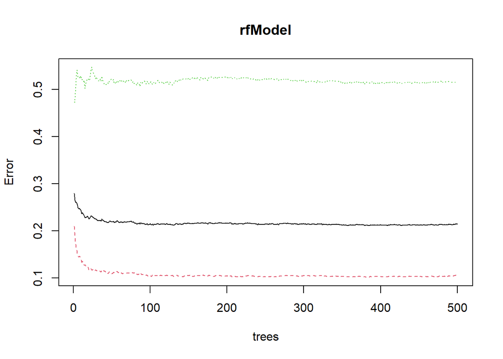

```r
plot(rfModel)
```

Good ratio to predict ‘No’, but higher error ratio for ‘Yes’

Predicting with test values

```r
pred_rf <- predict(rfModel, testing)
```

Confusion Matrix

```r
print("Random Forest Confusion Matrix"); table(testing$Churn, pred_rf)
```

```
## [1] "Random Forest Confusion Matrix"
```

```
##    pred_rf
##       No  Yes
##   0 1384  164
##   1  282  278
```

Recursos mais importantes

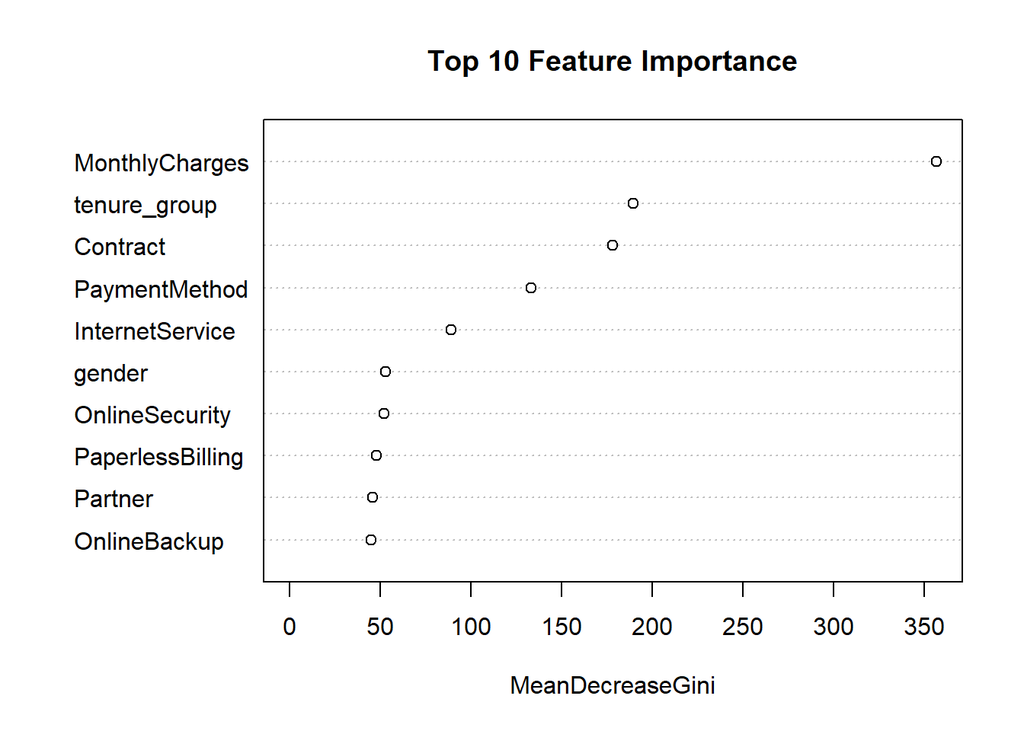

```r
varImpPlot(rfModel, sort=T, n.var = 10, main = 'Top 10 Feature Importance')
```